# Risk Terrain Model for Crime Prediction

Huiling He

## Introduction

This is an R Markdown document I created for one of my school project, which uses the Risk Terrain Model (RTM) for crime prediction. The purpose of creating this file is to show my codes and the process of my analysis more clearly. This code is also replicable and can be applied in other cases with different dataset.

In this RTM model, I choose 12 statistically significant factors and build a poission regression. Then I compare the result of this model to the result generated in ArcMap. In ArcMap, what is commonly used in predicting crime is using the kernal density to generate the hot spot map of crimes. However, the comparison shows that the RTM is doing better at predicting the count of crime than the traditional kernal density map. This discovery may improve the accuracy of the crime prediction and help the police office to allocate their resources more efficiently.

## Basic Settings and Regression Analysis

The following codes set up a map and color theme to generate maps.

```r
mapTheme <- function(base_size = 12) {
  theme(
    text = element_text( color = "black"),
    plot.title = element_text(size = 14,colour = "black"),
    plot.subtitle=element_text(face="italic"),
    plot.caption=element_text(hjust=0),
    axis.ticks = element_blank(),
    panel.background = element_blank(),axis.title = element_blank(),
    axis.text = element_blank(),
    axis.title.x = element_blank(),
    axis.title.y = element_blank(),
    panel.grid.minor = element_blank(),
    panel.border = element_rect(colour = "black", fill=NA, size=2)
  )
}

pallete4_10_colors <- c("#E8DB4C","#E2B645","#DC923E","#D66D37","#D14931","#AF483E","#8D474B","#6B4758","#494665","#274672")
```

Then reads the assaults data from my local files.

```r
assaults <- st_read("fishnet_jointed_variables_assaults.shp")
assaults2 <- assaults[, c(1,3:6,8:14, 17:20)]
```

```r
reg <- glm(Assa_count ~ ., family = "poisson",
            data= assaults2 %>%
              as.data.frame() %>%
              dplyr:: select(-Id,-geometry))
summary(reg)
```

```
##
## Call:
## glm(formula = Assa_count ~ ., family = "poisson", data = assaults2 %>%
##     as.data.frame() %>% dplyr::select(-Id, -geometry))
##
## Deviance Residuals:
##     Min       1Q   Median       3Q      Max
## -4.7447  -0.9215  -0.6199  -0.0009  23.8508
##
## Coefficients:
##               Estimate Std. Error z value Pr(>|z|)
## (Intercept)  1.299e-01  3.377e-02   3.848 0.000119 ***
## DISTSTLITE  -2.785e-04  3.256e-05  -8.552  < 2e-16 ***
## DISTABANB   -2.218e-04  1.179e-05 -18.818  < 2e-16 ***
## DISTABANC    8.868e-05  1.004e-05   8.830  < 2e-16 ***
## DISTBARS     5.641e-05  6.975e-06   8.087 6.13e-16 ***
## DISTBUS     -3.132e-04  2.016e-05 -15.532  < 2e-16 ***
## DISTCBD     -4.302e-06  5.435e-07  -7.916 2.46e-15 ***
## DISTFFOOD   -1.722e-04  1.266e-05 -13.597  < 2e-16 ***
## DISTGAS      2.085e-06  4.738e-06   0.440 0.659944
## DISTGRCRY   -8.581e-05  1.301e-05  -6.594 4.27e-11 ***
## DISTLAUDR   -3.179e-06  3.371e-06  -0.943 0.345544
## DISTSCHL    -3.256e-04  1.220e-05 -26.686  < 2e-16 ***
## abanB        3.867e-03  1.055e-04  36.662  < 2e-16 ***
## Groc         1.183e-02  4.586e-04  25.795  < 2e-16 ***
## StrLight     1.445e-03  1.203e-04  12.010  < 2e-16 ***
## ---
## Signif. codes:  0 '***' 0.001 '**' 0.01 '*' 0.05 '.' 0.1 ' ' 1
##
## (Dispersion parameter for poisson family taken to be 1)
##
##     Null deviance: 56333  on 35476  degrees of freedom
## Residual deviance: 42785  on 35462  degrees of freedom
## AIC: 63210
##
## Number of Fisher Scoring iterations: 7
```

```r
reg2 <- glm(Assa_count ~ ., family = "poisson",
           data= assaults2 %>%
             as.data.frame() %>%
             dplyr:: select(-Id,-geometry, -DISTGAS, -DISTLAUDR))
summary(reg2)
```

```
##
## Call:
## glm(formula = Assa_count ~ ., family = "poisson", data = assaults2 %>%
##     as.data.frame() %>% dplyr::select(-Id, -geometry, -DISTGAS,
##     -DISTLAUDR))
##
## Deviance Residuals:
##     Min       1Q   Median       3Q      Max
## -4.7326  -0.9214  -0.6204  -0.0009  23.8316
##
## Coefficients:
##               Estimate Std. Error z value Pr(>|z|)
## (Intercept)  1.268e-01  3.363e-02   3.769 0.000164 ***
## DISTSTLITE  -2.779e-04  3.256e-05  -8.535  < 2e-16 ***
## DISTABANB   -2.212e-04  1.175e-05 -18.823  < 2e-16 ***
## DISTABANC    8.772e-05  9.847e-06   8.909  < 2e-16 ***
## DISTBARS     5.596e-05  6.928e-06   8.077 6.63e-16 ***
## DISTBUS     -3.134e-04  2.012e-05 -15.573  < 2e-16 ***
## DISTCBD     -4.337e-06  5.181e-07  -8.370  < 2e-16 ***
## DISTFFOOD   -1.718e-04  1.262e-05 -13.617  < 2e-16 ***
## DISTGRCRY   -8.665e-05  1.294e-05  -6.694 2.17e-11 ***
## DISTSCHL    -3.254e-04  1.219e-05 -26.692  < 2e-16 ***
## abanB        3.865e-03  1.048e-04  36.883  < 2e-16 ***
## Groc         1.186e-02  4.577e-04  25.910  < 2e-16 ***
## StrLight     1.442e-03  1.203e-04  11.988  < 2e-16 ***
## ---
## Signif. codes:  0 '***' 0.001 '**' 0.01 '*' 0.05 '.' 0.1 ' ' 1
##
## (Dispersion parameter for poisson family taken to be 1)
##
##     Null deviance: 56333  on 35476  degrees of freedom
## Residual deviance: 42786  on 35464  degrees of freedom
## AIC: 63207
##
## Number of Fisher Scoring iterations: 7
```

Then I use the second model to predict the counts of crimes and map it.

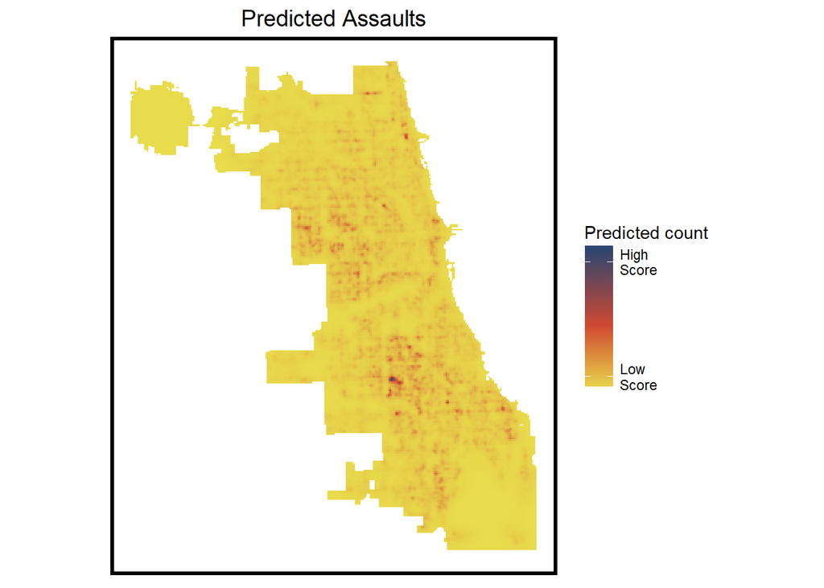

```r
predict <- cbind(assaults2,reg2$fitted.values)

ggplot() +
  geom_sf(data=predict, aes(fill=reg2.fitted.values), colour=NA) +
  labs(title= "Predicted Assaults") +
  theme(plot.title = element_text(hjust = 0.5)) +
  scale_fill_gradientn(colors = pallete4_10_colors,
                       breaks = c(1,10), labels = c("Low\nScore","High\nScore"),
                       name = "Predicted count") +
  mapTheme()
```

```r
write.csv(predict, "RMToutcome.csv")
```

In order to compare the importance of the variables, I plot the standardized coefficients and sort them descendingly based on their absolute values.

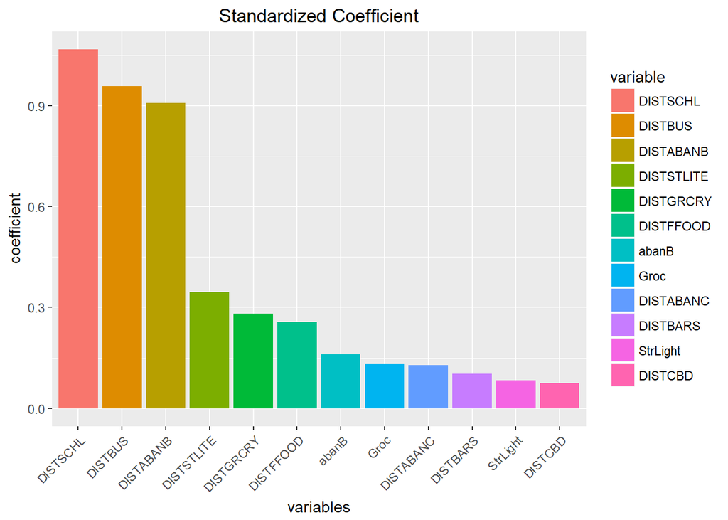

```r
standardized <- as.data.frame(lm.beta(reg2))
standardized$variable <- row.names(standardized)
colnames(standardized)[1] <- "std_coefficient"
standardized$absCoef <- abs(standardized$std_coefficient)

ggplot(standardized, aes(x=reorder(variable,-absCoef), y=absCoef, fill=reorder(variable,-absCoef))) +
  geom_bar(stat="identity") +
  theme(plot.title = element_text(hjust=0.5),
        axis.text.x = element_text(angle = 45, hjust = 1)) +
  labs(title = "Standardized Coefficient", x = "variables", y = "coefficient", fill="variable")
```

## Comparing Results from Kernel Density Maps in ArcGIS and RTM Model

When testing the goodness of fit, I compare the result of the RMT model and four kernel density maps with four different search radius. Notice that for kernel density map, as the search radius increase, the percent of correctly predicted cases on higher risk level increase as well, but compared to RMT model, it is still very low. In the real world, we want our model to do well in predicting areas with higher risk level, and from the bar chart we can see that when predicting for areas with higher risk level, RMT model works much better than kernel density model. That is what we want.

The codes below read the results of the kernel density map exported from ArcGIS, combine the dataset to the result of the RTM model and standardize the classification.

```r
countComparisons <- read.csv("countComparisons2.txt")

countComparisons <- cbind(
  countComparisons,
  data.frame(Category = c("90% - 100%", "70% - 89%", "50% - 69%", "30% - 49%", "1% - 29%")))

countComparisons <-
  countComparisons %>%
  dplyr::mutate(fittedPct = fittedCoun / sum(fittedCoun),
                kernelPct1 = kern500 / sum(kern500),
                kernelPct2 = kern1000 / sum(kern1000),
                kernelPct3 = kern1500 / sum(kern1500),
                kernelPct4 = kern2000 / sum(kern2000))

countComparisonsLong <-
  countComparisons %>%
  gather(Variable, Value, fittedPct:kernelPct4)
```

And below is the code chunk and the chart comparing the results of kernel density and RTM model, which shows that the RTM model is doing a better job at predicting crimes than kernel density maps.

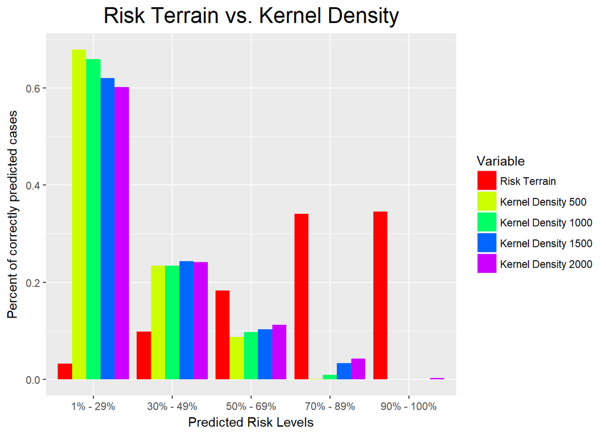

```r
ggplot(data=countComparisonsLong, aes(Category,Value), color=set1) +
  geom_bar(aes(fill = Variable), position = "dodge", stat="identity") +
  theme(plot.title = element_text(size=18, hjust=0.5)) +
  scale_fill_manual(values=rainbow(5),
                    labels=c("Risk Terrain", "Kernel Density 500",
                             "Kernel Density 1000", "Kernel Density 1500", "Kernel Density 2000")) +
  labs(x= "Predicted Risk Levels",
       y="Percent of correctly predicted cases",
       title= "Risk Terrain vs. Kernel Density")
```